# hw3

Ritika Agrawal

February 19, 2020

# Homework #3

## Ritika Agrawal ; ritikagrawal1710

## Tips at Restaurants

In this homework we will use the `tips` data set. This data set is part of the `reshape2` package. You can load the data set by executing the command:

```r
library(dplyr)
```

```r
library(ggplot2)
data(tips, package="reshape2")
head(tips)
```

```
##   total_bill  tip    sex smoker day   time size
## 1      16.99 1.01 Female     No Sun Dinner    2
## 2      10.34 1.66   Male     No Sun Dinner    3
## 3      21.01 3.50   Male     No Sun Dinner    3
## 4      23.68 3.31   Male     No Sun Dinner    2
## 5      24.59 3.61 Female     No Sun Dinner    4
## 6      25.29 4.71   Male     No Sun Dinner    4
```

If you do not have available the package `reshape2`, issue `install.packages('reshape2')` to install it. The information contained in the data is collected by one waiter, who recorded over the course of a season information about each tip he received working in one restaurant. See `?tips` for a description of all of the variables.

**Submission instructions**: Create a folder named `ds202_hw3`, and name the RMarkDown file `hw3.Rmd` which should include your solutions under this folder. For submission, create a GitHub repository named `ds202_hw3` under your GitHub account, and push both `hw3.Rmd` and the knitted `hw3.html` before the deadline. I will assume you use the same GitHub username as for your HW2 submission. The latest version of your homework appearing on GitHub before the deadline is graded. *It is crucial to follow the exact folder structure and file names*, so that your homework can be reproduced and graded by an automated script. This homework is **due on Feb 19** before class.

1. How many parties did the waiter serve? Store the number in `numParty` and print.

```r
numParty = nrow(tips)
numParty
```

```
## [1] 244
```

2. What are the types of variables in the data frame `tips`? Include the code and also explain verbally.

```r
head(tips)
```

```
##   total_bill  tip    sex smoker day   time size
## 1      16.99 1.01 Female     No Sun Dinner    2
## 2      10.34 1.66   Male     No Sun Dinner    3
## 3      21.01 3.50   Male     No Sun Dinner    3
## 4      23.68 3.31   Male     No Sun Dinner    2
## 5      24.59 3.61 Female     No Sun Dinner    4
## 6      25.29 4.71   Male     No Sun Dinner    4
```

```r
summary(tips)
```

```
##    total_bill         tip             sex      smoker      day         time
##  Min.   : 3.07   Min.   : 1.000   Female: 87   No :151   Fri :19   Dinner:176
##  1st Qu.:13.35   1st Qu.: 2.000   Male  :157   Yes: 93   Sat :87   Lunch : 68
##  Median :17.80   Median : 2.900                          Sun :76
##  Mean   :19.79   Mean   : 2.998                          Thur:62
##  3rd Qu.:24.13   3rd Qu.: 3.562
##  Max.   :50.81   Max.   :10.000
##       size
##  Min.   :1.00
##  1st Qu.:2.00
##  Median :2.00
##  Mean   :2.57
##  3rd Qu.:3.00
##  Max.   :6.00
```

Response: ‘tips’ is dependent variable. The others are independent variables. The variables, total_bill, size are numerical and the variables sex, smoker,day,time are categorical variables

3. Create a vector named `day` containing the day of visits in `tips`. The factor levels should be ordered from Thursday to Sunday. Print the variable.

```r
my_group <- group_by(tips, day)
day=summarize(my_group, Value = n())
day$day <- factor(day$day, levels= c("Monday",
                                         "Tuesday", "Wednesday", "Thur", "Fri", "Sat","Sun"))
day = day[order(day$day), ]
day
```

```
## # A tibble: 4 x 2
##   day   Value
##   <fct> <int>
## 1 Thur     62
## 2 Fri      19
## 3 Sat      87
## 4 Sun      76
```

4. Create a data frame named `female5` containing the meal paid by a female payer in a party with size greater than or equal to 5. Print the data frame.

```r
female5 <- subset(tips, size >= 5 & sex == "Female")
head(female5)
```

```
##     total_bill  tip    sex smoker  day   time size
## 126      29.80 4.20 Female     No Thur  Lunch    6
## 144      27.05 5.00 Female     No Thur  Lunch    6
## 156      29.85 5.14 Female     No  Sun Dinner    5
```

5. How does the tipping amount (`tip`) depend on the overall bill (`total_bill`)? Use the `ggplot2` package to make a chart. Describe the relationship in words.

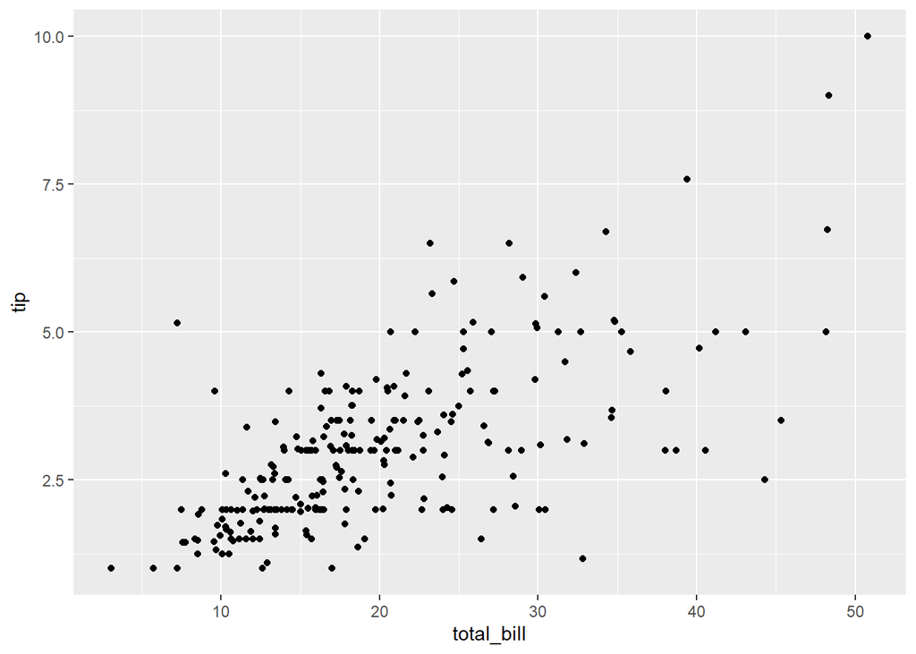

```r
ggplot(tips, aes(x=total_bill, y=tip)) + geom_point()
```

Response: Relation seems to be linear

6. Describe at least two types of anomalies in the previous plot. What do they mean?

Response: If we see the data points 32,2 and 7,5, these are called outliers which do not follow the pattern as most other data points.

7. Introduce a variable `tiprate` into the data set which stands for the rate of tips. What is the average rate for tips? Explain verbally.

```r
tips$rate <- tips$tip/tips$total_bill
head(tips$rate)
```

```
## [1] 0.05944673 0.16054159 0.16658734 0.13978041 0.14680765 0.18623962
```

```r
average_rate = summary(tips$rate)[4]
average_rate
```

```
##      Mean
## 0.1608026
```

8. Make a boxplot of the tip rate by time. The x-axis should be ordered by lunch and then dinner. Use `ggplot2` to make a chart. Verbally explain the chart.

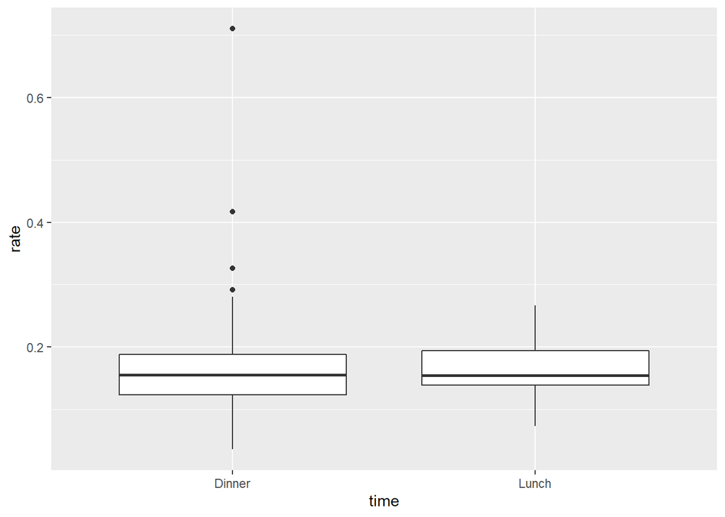

```r
p <- ggplot(tips, aes(x=time, y=rate)) +
  geom_boxplot()
p
```

9. How does smoking behavior and gender of the person who pays impact the relationship between tip and total bill? Find a visualization that incorporates all four variables. Interpret the result.

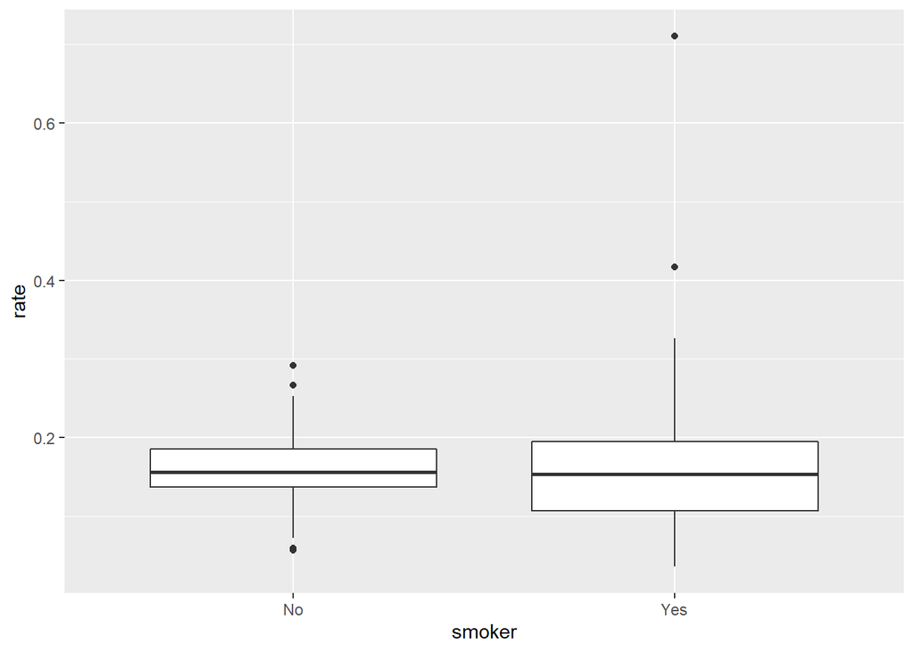

```r
a <- ggplot(tips, aes(x=smoker, y=rate)) +
  geom_boxplot()
a
```

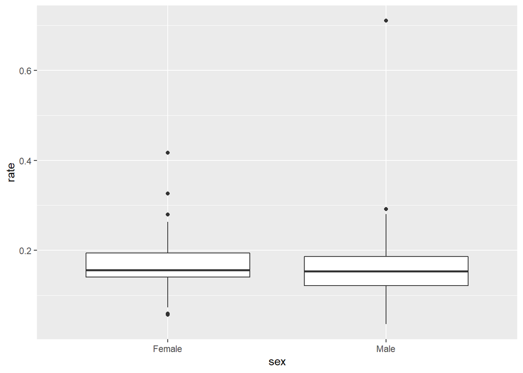

```r
b <- ggplot(tips, aes(x=sex, y=rate)) +
  geom_boxplot()
b
```

10. Use ggplot2 to find a graphical summary of the relationship between day of the week and gender of the person paying the bill. What can you say about this relationship?

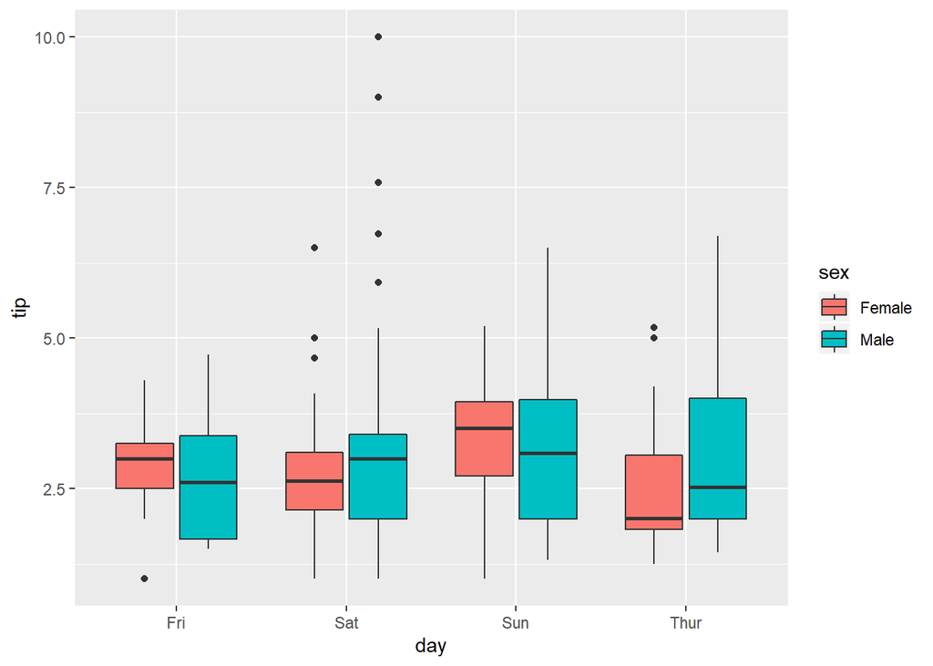

```r
ggplot(aes(y = tip, x = day, fill = sex), data = tips) + geom_boxplot()
```

Note: your submission is supposed to be fully reproducible, i.e. the TA and I will ‘knit’ your submission in RStudio.